# Scratch analysis

Kristian Brock

09 September, 2019

```r
# This script in the root of the project loads the datasets
source('../../../Load.R')

dlt_fitted_draws <- readRDS('dlt_fitted_draws.rds')

# This script loads objects specific to this modelling task.
# It relies on dlt_fitted_draws being loaded.
source('ModellingObjects.R')
```

# DLT

Num series

```r
dlt %>% count(AnalysisSeriesId) %>% nrow # 155 series
```

```
[1] 155
```

Select random n:

```r
dlt %>% count(AnalysisSeriesId) %>% sample_n(5)
```

| AnalysisSeriesId | n |
| --- | --- |
| 313 | 2 |
| 348 | 2 |
| 229 | 10 |
| 137 | 4 |
| 39 | 2 |

## Series analysis

Series of interest are:

- ‘Atzori2011_1’
- ‘Sessa2013_1’
- ‘Smith2011_1’
- ‘Borghaei2009_1’
- ‘Finn2013_1’
- ‘Jones2012_1’
- ‘Farid2012_1’

The bottom two have problems fitting in ML method but not in Bayes.

```r
dlt %>%
  filter(Study == 'Atzori2011_1') %>%
  distinct(AnalysisSeriesId) %>%
  head(1) %>% .[[1]] -> series_id

series_id
```

```
[1] 433
```

#### Raw data

```r
dlt %>% filter(AnalysisSeriesId == series_id)
```

| Study | AnalysisSeriesId | Dose | DoseLevel | n | Events | ProbEvent |
| --- | --- | --- | --- | --- | --- | --- |
| Atzori2011_1 | 433 | 1.25mg/kg once weekly | -2.5 | 5 | 0 | 0.000 |
| Atzori2011_1 | 433 | 2.5mg/kg once weekly | -1.5 | 3 | 0 | 0.000 |
| Atzori2011_1 | 433 | 5mg/kg once weekly | -0.5 | 8 | 1 | 0.125 |
| Atzori2011_1 | 433 | 10mg/kg once weekly | 0.5 | 13 | 0 | 0.000 |
| Atzori2011_1 | 433 | 15mg/kg once weekly | 1.5 | 13 | 0 | 0.000 |
| Atzori2011_1 | 433 | 20mg/kg once weekly | 2.5 | 16 | 0 | 0.000 |

#### GLM model

```r
dlt %>% filter(AnalysisSeriesId == series_id) %>%
  glm(ProbEvent ~ DoseLevel, data = ., weights = n,
      family = binomial('logit'))
```

```
Call:  glm(formula = ProbEvent ~ DoseLevel, family = binomial("logit"),
    data = ., weights = n)

Coefficients:
(Intercept)    DoseLevel
    -3.9624      -0.4788

Degrees of Freedom: 5 Total (i.e. Null);  4 Residual
Null Deviance:      4.075
Residual Deviance: 3.449    AIC: 9.319
```

#### Analysis (with title)

```r
dlt_analysis <- analyse_dlt(
  series_id = dlt %>% filter(Study == 'Atzori2011_1') %>%
    distinct(AnalysisSeriesId) %>% head(1) %>% .[[1]],
  alpha = alpha, add_title = TRUE)
```

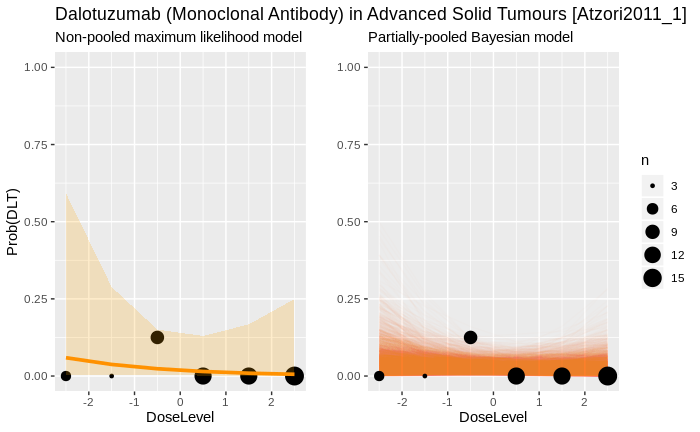

```r
library(patchwork)
dlt_analysis$p1 + dlt_analysis$p2
```

CI comparison between partially-pooled and non-pooled analyses:

```r
library(tidyr)
dlt_analysis$ci_inferences %>%
  select(Method, .ci.width.l, DoseLevel) %>%
  spread(Method, .ci.width.l) %>%
  mutate(
    ReductionInCI = PartiallyPooled / NonPooled - 1,
    EffectiveNMultipler = (NonPooled / PartiallyPooled)^2
  ) %>% print(n = 100)
```

| DoseLevel | NonPooled | PartiallyPooled | ReductionInCI | EffectiveNMultipler |
| --- | --- | --- | --- | --- |
| -2.5 | 6.275006 | 4.141123 | -0.3400607 | 2.296107 |
| -1.5 | 4.682905 | 3.201468 | -0.3163501 | 2.139599 |
| -0.5 | 3.982254 | 2.615988 | -0.3430886 | 2.317322 |
| 0.5 | 4.600212 | 2.680122 | -0.4173916 | 2.946093 |
| 1.5 | 6.151456 | 3.291014 | -0.4650024 | 3.493786 |
| 2.5 | 8.117495 | 4.277146 | -0.4730953 | 3.601935 |

# Next steps:

Batch, convey drug-types as colours

Talk plan:

1. Plot the points
2. Add the smooth plus SE
3. Add conjectured inverted line
4. Or slightly weird wavey line
5. Or datasaurus line
6. How do I know these are not the truth? Where is that information coming from? Because it is not coming from the trial data.
7. Show the Bayesian posterior draw lines

Show some more examples to show that the locations (means) are not shifted but that the uncertainties (SDs) are reduced. Consider making all 130 slides and asking the audience select slides.

8. Present the effective sample size increases and say why aren;t you Bayes?

Propose the alternative title for this talk: A Bayesian re-analysis of 130 dose-finding trials, with regularisation provided by partial pooling to overcome the severe limitation of perenially small sample size to produce inference on the dose-event probabilities of modern classes of cancer drugs.

Further benefits:

- Bayesian model fits all datasets.
- Sometimes non-pooled model fails to fit:
- E.g. series_id = 192
- Or gives silly inference (no events, event rate has 0-1 CI)
- E.g. series_id = 201, although this example is chemo and the CI is
- questionable.